# R Notebook

## The statistical analysis of live global coronavirus datasets and association of the diet patterns in relation to the deaths from COVID-19

```r
library(magrittr)
library(readr)
library(cluster)
library(factoextra)
library(readxl)
library(dendextend)
library(gridExtra)
library(dplyr)
library(ggplot2)
library(arules)
library(arulesViz)
library(tidyverse)
library(scales)
```

### Loading Data

The below dataset used in the project is the collection of Covid-19 data maintained by *Our World in Data*.

```r
covid <- read_csv("https://raw.githubusercontent.com/owid/covid-19-data/master/public/data/owid-covid-data.csv",
    col_types = cols(iso_code = col_skip(), date = col_skip()))

dim(covid)
```

```
## [1] 108671     58
```

### Data Pre-processing

1.Renaming the variable *location* as *Country* and grouping the dataset by Country.  
2.Summarizing the columns using the max function as the required variables data is cummulated for each day in the dataset.

```r
covid <-covid %>%
  rename(
    Country = location,
      )

covid <- covid %>%
    group_by(Country) %>%
    summarize_at(c("total_cases", "total_deaths","total_tests",
                   "total_vaccinations","population","population_density","median_age","aged_65_older","aged_70_older"
                   ), max, na.rm = TRUE) %>% ungroup()
is.na(covid)<-sapply(covid, is.infinite)
covid
```

```
## # A tibble: 232 x 10
##    Country      total_cases total_deaths total_tests total_vaccinati~ population
##    <chr>              <dbl>        <dbl>       <dbl>            <dbl>      <dbl>
##  1 Afghanistan       151013         6961          NA          1767239   38928341
##  2 Africa           7083510       178796          NA         78303927 1340598113
##  3 Albania           134201         2460      737014          1280239    2877800
##  4 Algeria           183347         4618          NA          4146091   43851043
##  5 Andorra            14873          129      204740            82349      77265
##  6 Angola             43890         1057          NA          1695588   32866268
##  7 Anguilla              NA           NA          NA            18457      15002
##  8 Antigua and~        1348           43       16700            69903      97928
##  9 Argentina        5041487       108165    12442184         35247776   45195777
## 10 Armenia           232610         4658     1372405           194902    2963234
## # ... with 222 more rows, and 4 more variables: population_density <dbl>,
## #   median_age <dbl>, aged_65_older <dbl>, aged_70_older <dbl>
```

### Data Cleaning

1.Omitting the null values from required columns.  
2.Creating a new variable Death by Population.

```r
covid_age<-covid %>% filter(!is.na(covid$median_age) & !is.na(covid$total_deaths) & !is.na(covid$aged_65_older) &   !is.na(covid$population))

covid_age$deaths_by_population <- (covid_age$total_deaths/covid_age$population)

covid_age
```

```
## # A tibble: 178 x 11
##    Country      total_cases total_deaths total_tests total_vaccinati~ population
##    <chr>              <dbl>        <dbl>       <dbl>            <dbl>      <dbl>
##  1 Afghanistan       151013         6961          NA          1767239   38928341
##  2 Albania           134201         2460      737014          1280239    2877800
##  3 Algeria           183347         4618          NA          4146091   43851043
##  4 Angola             43890         1057          NA          1695588   32866268
##  5 Antigua and~        1348           43       16700            69903      97928
##  6 Argentina        5041487       108165    12442184         35247776   45195777
##  7 Armenia           232610         4658     1372405           194902    2963234
##  8 Australia          37377          945    26751476         13958045   25499881
##  9 Austria           664133        10751    69283203         10039144    9006400
## 10 Azerbaijan        354662         5084     4133796          5478042   10139175
## # ... with 168 more rows, and 5 more variables: population_density <dbl>,
## #   median_age <dbl>, aged_65_older <dbl>, aged_70_older <dbl>,
## #   deaths_by_population <dbl>
```

### **Part -1 : Association of deaths and median age & older population**

### Analyzing the data using scatter plots

1. Deaths vs Median Age
2. Deaths vs Aged_65_older

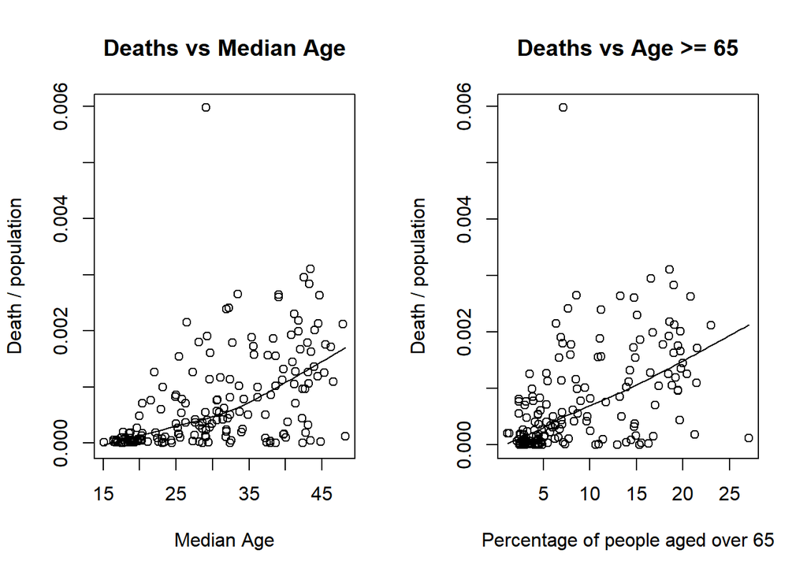

```r
par(mfrow=c(1,2))
scatter.smooth(y=covid_age$deaths_by_population , x=covid_age$median_age, main="Deaths vs Median Age",xlab = "Median Age", ylab = "Death / population")
scatter.smooth(y=covid_age$deaths_by_population , x=covid_age$aged_65_older, main="Deaths vs Age >= 65" ,xlab = "Percentage of people aged over 65", ylab = "Death / population")
```

### Plotting the box plots

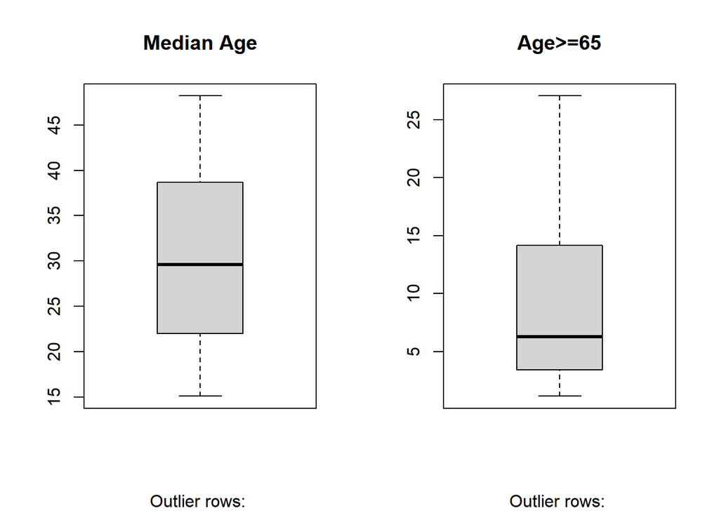

```r
par(mfrow=c(1,2))
boxplot(covid_age$median_age,main="Median Age",  sub=paste("Outlier rows:", boxplot.stats(covid_age$median_age)$out))
boxplot(covid_age$aged_65_older,main="Age>=65",  sub=paste("Outlier rows:", boxplot.stats(covid_age$aged_65_older)$out))
```

The box plot above show that there are no outliers in the data and doesnt require any outliers removal.

### Correlation-Analysis

```r
cor(covid_age$deaths_by_population, covid_age$median_age)
```

```
## [1] 0.5107315
```

```r
cor(covid_age$deaths_by_population, covid_age$aged_65_older)
```

```
## [1] 0.5083417
```

The above correlation values corrobarate that the countries with high Median age and more population aged over 65 have more deaths.

### Linear Regression

Splitting the data to train and test.

```r
index <- sort(sample(nrow(covid_age), 0.8 * nrow(covid_age)))
data_train <-covid_age[index,]
data_test <-covid_age[-index,]
```

### Building the Linear Regression model for Median age data and printing the summary

```r
linearModMA <-  lm(deaths_by_population~ median_age, data = data_train)
summary(linearModMA)
```

```
##
## Call:
## lm(formula = deaths_by_population ~ median_age, data = data_train)
##
## Residuals:
##        Min         1Q     Median         3Q        Max
## -0.0014077 -0.0003730 -0.0001158  0.0002682  0.0052887
##
## Coefficients:
##               Estimate Std. Error t value Pr(>|t|)
## (Intercept) -8.985e-04  2.237e-04  -4.017 9.58e-05 ***
## median_age   5.456e-05  7.006e-06   7.787 1.38e-12 ***
## ---
## Signif. codes:  0 '***' 0.001 '**' 0.01 '*' 0.05 '.' 0.1 ' ' 1
##
## Residual standard error: 0.0007725 on 140 degrees of freedom
## Multiple R-squared:  0.3022, Adjusted R-squared:  0.2972
## F-statistic: 60.64 on 1 and 140 DF,  p-value: 1.383e-12
```

Using the above model to predict the test data and comparing the predicated data with the original data

```r
predMA <- predict(linearModMA,  data_test)
actualMA  <- data.frame(cbind(actuals=(data_test$deaths_by_population), predicted=predMA))
actualMA
```

```
##         actuals    predicted
## 1  1.788157e-04 1.163430e-04
## 2  3.705900e-05 1.169354e-03
## 3  5.014215e-04 8.692729e-04
## 4  1.406344e-04 6.019282e-04
## 5  2.657012e-03 9.292890e-04
## 6  6.857409e-06 8.692729e-04
## 7  5.025265e-05 1.272551e-04
## 8  2.029085e-05 9.997500e-05
## 9  3.243875e-05 1.381671e-04
## 10 1.014700e-03 9.347450e-04
## 11 1.170147e-05 2.904683e-05
## 12 8.767022e-05 3.236715e-04
## 13 7.662710e-04 2.745674e-04
## 14 6.053395e-04 3.509516e-04
```

[output cut: 22 more lines]

### Plotting the actual data, the predicted data of deaths by population into a figure

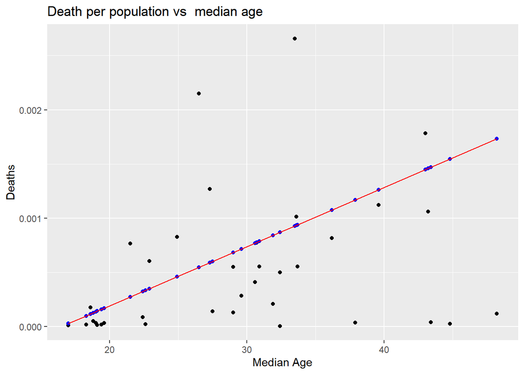

```r
ggplot(data = data_test) + geom_point(aes(x = median_age,y = deaths_by_population)) + geom_point(aes(x = median_age,y = actualMA$predicted), color="blue") + geom_line(aes(x = median_age,y = actualMA$predicted), color = "red") + ggtitle("Death per population vs  median age ")+ylab("Deaths")+xlab("Median Age")
```

The above linear regression plot corroborates the evidence that the positive association between the country’s deaths and their median age.

### Building the Linear Regression model for Aged_65_over data and printing the summary

```r
linearModOA <-  lm(deaths_by_population ~ aged_65_older , data = data_train)
summary(linearModOA)
```

```
##
## Call:
## lm(formula = deaths_by_population ~ aged_65_older, data = data_train)
##
## Residuals:
##        Min         1Q     Median         3Q        Max
## -0.0015847 -0.0003012 -0.0001998  0.0002595  0.0053631
##
## Coefficients:
##                Estimate Std. Error t value Pr(>|t|)
## (Intercept)   3.100e-05  1.139e-04   0.272    0.786
## aged_65_older 8.163e-05  1.038e-05   7.867 8.88e-13 ***
## ---
## Signif. codes:  0 '***' 0.001 '**' 0.01 '*' 0.05 '.' 0.1 ' ' 1
##
## Residual standard error: 0.0007701 on 140 degrees of freedom
## Multiple R-squared:  0.3066, Adjusted R-squared:  0.3016
## F-statistic: 61.89 on 1 and 140 DF,  p-value: 8.883e-13
```

### Using the above model to predict the test data and comparing the predicated data with the original data

```r
predOA <- predict(linearModOA,  data_test)
actualOA  <- data.frame(cbind(actuals=(data_test$deaths_by_population), predicted=predOA))
actualOA
```

```
##         actuals    predicted
## 1  1.788157e-04 0.0002417042
## 2  3.705900e-05 0.0012966718
## 3  5.014215e-04 0.0005222833
## 4  1.406344e-04 0.0004471793
## 5  2.657012e-03 0.0007291461
## 6  6.857409e-06 0.0004057904
## 7  5.025265e-05 0.0002893790
## 8  2.029085e-05 0.0003293801
## 9  3.243875e-05 0.0003087265
## 10 1.014700e-03 0.0008039237
## 11 1.170147e-05 0.0002775420
## 12 8.767022e-05 0.0002633375
## 13 7.662710e-04 0.0002892158
## 14 6.053395e-04 0.0004141988
```

[output cut: 22 more lines]

### Plotting the actual data, the predicted data of deaths by population into a figure

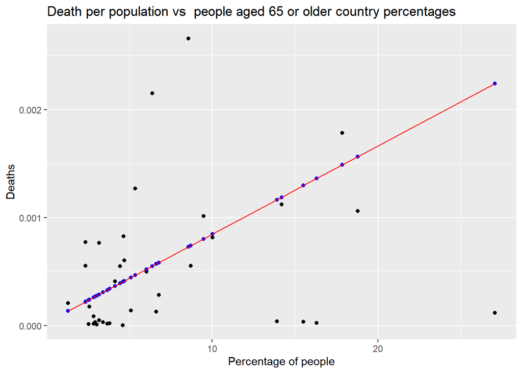

```r
ggplot(data = data_test) + geom_point(aes(x = aged_65_older,y = deaths_by_population)) + geom_point(aes(x = aged_65_older,y = actualOA$predicted), color="blue") + geom_line(aes(x = aged_65_older,y = actualOA$predicted), color = "red")+
  ggtitle("Death per population vs  people aged 65 or older country percentages")+ylab("Deaths")+xlab("Percentage of people")
```

The above linear regression plot corroborates the evidence that the positive association between the country’s deaths and 65 or older population.

### **Part -2 : Association of deaths and obesity factor**

### Loading Data

The dataset used below is the combination of the protein for different categories of food (all calculated as percentage of total intake amount) , world population obesity and undernourished rate from around the data in an effort to learn how healthy eating style helps in combating Covid.

```r
covid_pro <- read_csv("C:/Users/keert/Desktop/R programming/Protein_Supply_Quantity_Data.csv")
dim(covid_pro)
```

```
## [1] 170  32
```

### Data Pre-processing

1. Joining the covid dataset and countries protein intake dataset based on country.
2. Removing the null values from the required columns.

```r
covid_final <- left_join(covid,covid_pro, by="Country")
Obesity_clean<-covid_final%>% filter( !is.na(covid_final$Obesity)& !is.na(covid_final$total_deaths) &!is.na(covid_final$population))
Obesity_clean
```

```
## # A tibble: 151 x 41
##    Country      total_cases total_deaths total_tests total_vaccinati~ population
##    <chr>              <dbl>        <dbl>       <dbl>            <dbl>      <dbl>
##  1 Afghanistan       151013         6961          NA          1767239   38928341
##  2 Albania           134201         2460      737014          1280239    2877800
##  3 Algeria           183347         4618          NA          4146091   43851043
##  4 Angola             43890         1057          NA          1695588   32866268
##  5 Antigua and~        1348           43       16700            69903      97928
##  6 Argentina        5041487       108165    12442184         35247776   45195777
##  7 Armenia           232610         4658     1372405           194902    2963234
##  8 Australia          37377          945    26751476         13958045   25499881
##  9 Austria           664133        10751    69283203         10039144    9006400
## 10 Azerbaijan        354662         5084     4133796          5478042   10139175
## # ... with 141 more rows, and 35 more variables: population_density <dbl>,
## #   median_age <dbl>, aged_65_older <dbl>, aged_70_older <dbl>,
## #   Alcoholic Beverages <dbl>, Animal Products <dbl>, Animal fats <dbl>,
## #   Aquatic Products, Other <dbl>, Cereals - Excluding Beer <dbl>, Eggs <dbl>,
## #   Fish, Seafood <dbl>, Fruits - Excluding Wine <dbl>, Meat <dbl>,
## #   Milk - Excluding Butter <dbl>, Offals <dbl>, Oilcrops <dbl>, Pulses <dbl>,
## #   Spices <dbl>, Starchy Roots <dbl>, Stimulants <dbl>, Sugar Crops <dbl>, ...
```

Discretizing the values in the obesity variable into “low”, “medium”, “high”, “very high” levels

```r
Obesity_clean$Obese_level <- discretize(Obesity_clean$Obesity, method = "frequency", breaks = 4, labels = c("low", "medium", "high", "very high"))
```

### Plotting the total cases vs obesity levels

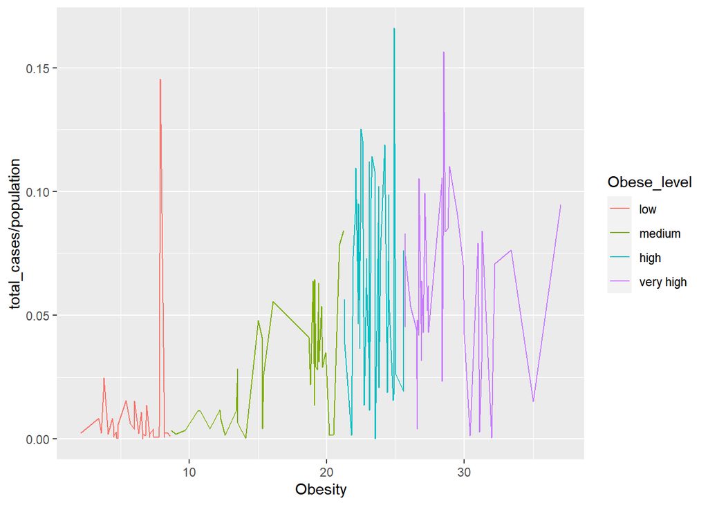

```r
ggplot(Obesity_clean, aes(x=Obesity, y=total_cases/population, color=Obese_level, group=Obese_level)) + geom_line()
```

### Plotting the total deaths vs obesity levels

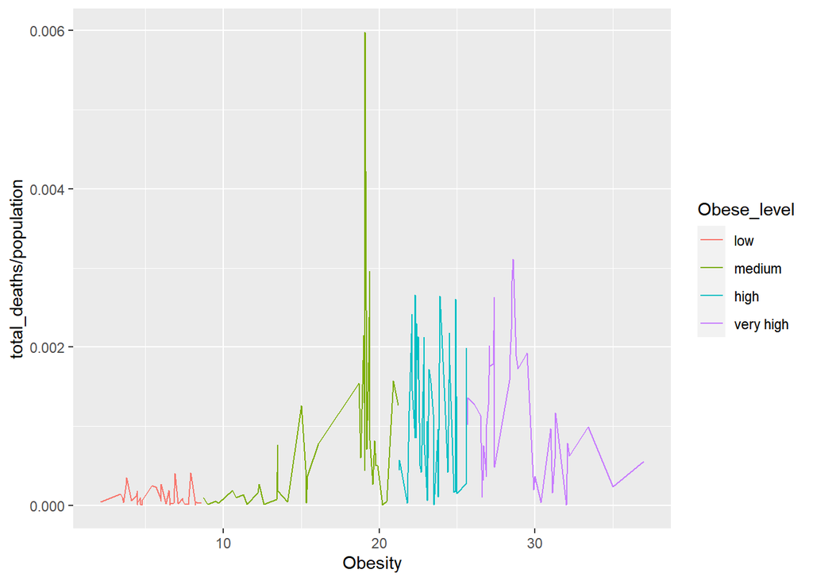

```r
ggplot(Obesity_clean, aes(x=Obesity, y=total_deaths/population, color=Obese_level, group=Obese_level)) + geom_line()
```

from the above plot it can be observed that the unusual spike observed in the above plot does not appear in this plot, from which we can also conclude that low obese people who were contracted the infection recovered.

### **Part-3 Association of death and protein intake from various sources using Kmeans clustering**

1.Selecting the required variables from the Protein intake dataset and omitting the Null values.  
2.Converting the column names to row names to plot the graph below for the cluster analysis.  
3. Rescaling the variables to manipulate certain numeric columns to a particular range.

```r
covidcluster <- select(covid_final,Country,`Animal fats`,`Animal Products`,Eggs,Meat,`Vegetal Products`,Obesity,total_deaths,population)
covidcluster<-na.omit(covidcluster)
covidcluster<-covidcluster %>% column_to_rownames(., var = "Country")
covidcluster$deaths_by_population <- (covidcluster$total_deaths/covidcluster$population)
covidcluster<- select(covidcluster,deaths_by_population,`Animal fats`,`Animal Products`, Eggs,Meat,`Vegetal Products`,Obesity)
covidcluster$deaths_by_population<-rescale(covidcluster$deaths_by_population)
covidcluster$`Animal fats`<-rescale(covidcluster$`Animal fats`)
covidcluster$`Animal Products`<-rescale(covidcluster$`Animal Products`)
covidcluster$Eggs<-rescale(covidcluster$Eggs)
covidcluster$Meat<-rescale(covidcluster$Meat)
covidcluster$`Vegetal Products`<-rescale(covidcluster$`Vegetal Products`)
covidcluster$Obesity<-rescale(covidcluster$Obesity)
```

### Determining the optimal value of K value using Average Silhouette method

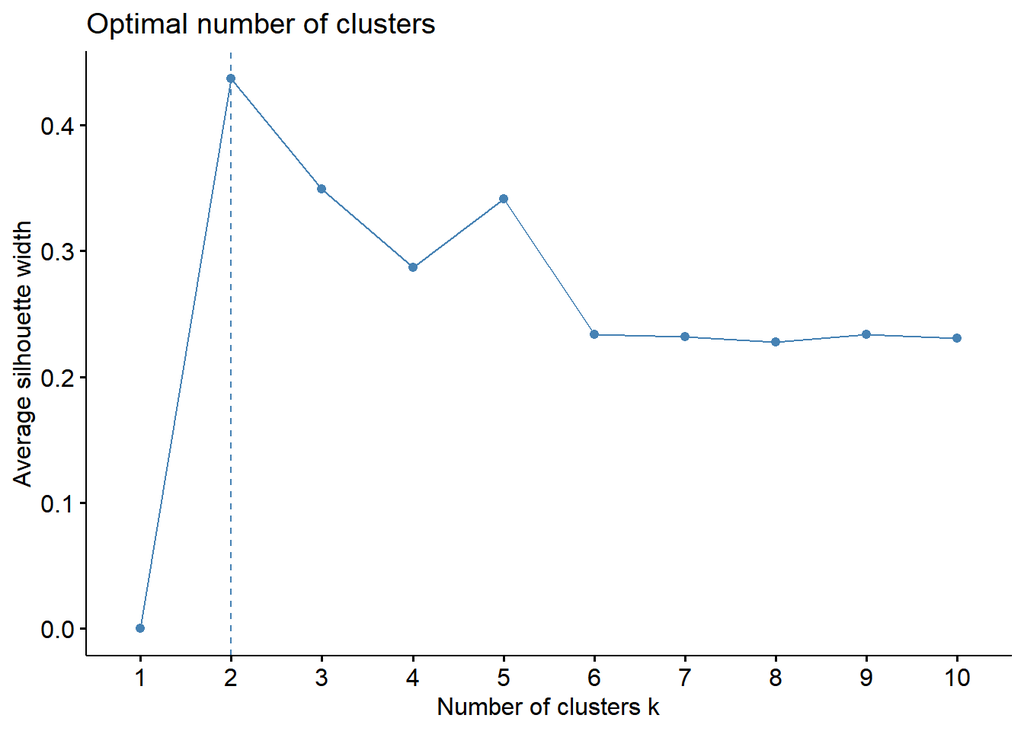

```r
fviz_nbclust(covidcluster, kmeans, method = "silhouette")
```

So using the silhouette we can see that the optimal number of cluster k =2

### Building K-Means model using the optimal K value

```r
k2 <- kmeans(covidcluster, centers = 2, nstart = 25)
```

### Using fviz_cluster to visualize the results

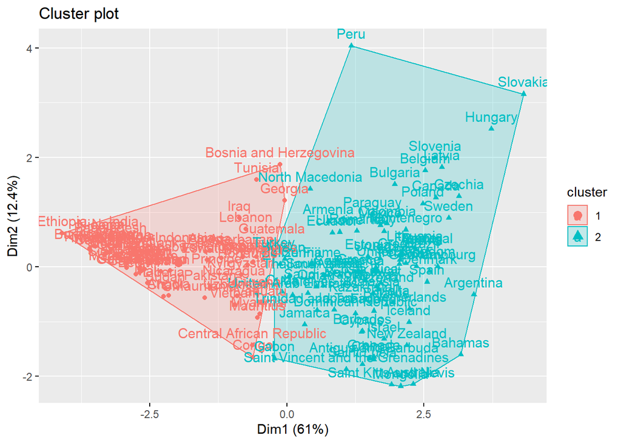

```r
fviz_cluster(k2, data = covidcluster)
```

The above graph shows that the group of countries cluster 1 and cluster 2 have similar similar kind of food intake, we can classify observations in k groups, based on their similarity.

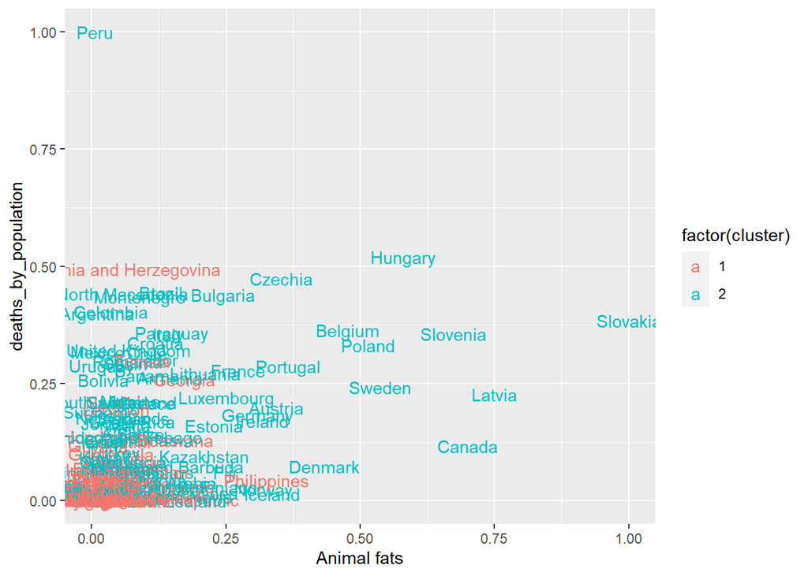

```r
covidcluster %>%
  as_tibble() %>%
  mutate(cluster = k2$cluster,
         Country = row.names(covidcluster)) %>%
  ggplot(aes(`Animal fats`,deaths_by_population,  color = factor(cluster), label = Country)) +
  geom_text()
```

```r
covidcluster2 <- aggregate(covidcluster, by=list(cluster=k2$cluster), mean)
covidcluster3 <- covidcluster2 %>% pivot_longer(names_to = "Factors", values_to = "Value", c(deaths_by_population,`Animal fats`,  `Animal Products`,Eggs , Meat ,`Vegetal Products`,Obesity))
```

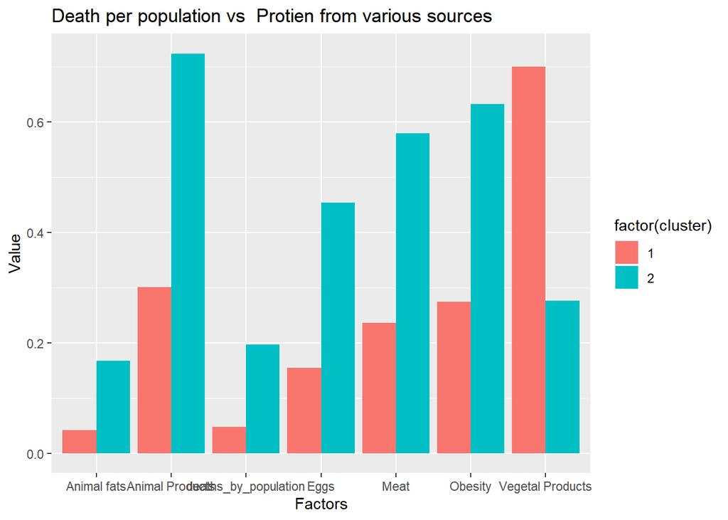

```r
ggplot(covidcluster3, aes(Factors, Value, fill = factor(cluster))) + geom_col(position = "dodge")+ggtitle("Death per population vs  Protien from various sources ")
```

The clustered centers plot of the protiens intake from various sources and the deaths and observed as the proteins intake through vegetal Products increased, the number of deaths decreased. But for all other sources like animal fats, animal products, eggs and Meat their consumption increased the deaths.

```r
covid_ar<-covid_final
```

### **Part-4 Association of countries and food intake from various sources using Association rules.**

Discretizing the values of the required variables in dataset into “low”, “moderate”, “high”

```r
covid_ar$total_deaths.bracket <- discretize(covid_ar$total_deaths, method = "frequency", breaks = 2, labels = c("low",  "high"))

covid_ar$Animalfats.consumption <- discretize(covid_ar$`Animal fats`, method = "frequency", breaks = 3, labels = c("low", "moderate", "high"))

covid_ar$AnimalProducts.consumption <- discretize(covid_ar$`Animal Products`, method = "frequency", breaks = 3, labels = c("low", "moderate", "high"))

covid_ar$Eggs.consumption <- discretize(covid_ar$Eggs, method = "frequency", breaks = 3, labels = c("low", "moderate", "high"))

covid_ar$Meat.consumption <- discretize(covid_ar$Meat, method = "frequency", breaks = 3, labels = c("low", "moderate", "high"))

covid_ar$VegetalProducts.consumption <- discretize(covid_ar$`Vegetal Products`, method = "frequency", breaks = 3, labels = c("low", "moderate", "high"))

covid_ar$Obesity.level <- discretize(covid_ar$Obesity, method = "frequency", breaks = 3, labels = c("low", "moderate", "high"))

covid_ar$CerealsExcludingBeer.consumption <- discretize(covid_ar$`Cereals - Excluding Beer`, method = "frequency", breaks = 3, labels = c("low", "moderate", "high"))

covid_ar$FishSeafood.consumption <- discretize(covid_ar$`Fish, Seafood`, method = "frequency", breaks = 3, labels = c("low", "moderate", "high"))

covid_ar$FruitsExcludingWine.consumption <- discretize(covid_ar$`Fruits - Excluding Wine`, method = "frequency", breaks = 3, labels = c("low", "moderate", "high"))

covid_ar$MilkExcludingButter.consumption <- discretize(covid_ar$`Milk - Excluding Butter`, method = "frequency", breaks = 3, labels = c("low", "moderate", "high"))
```

Convert the data into transactional data

```r
covid_ar_tr <- as(covid_ar[, sapply(covid_ar, is.factor)], "transactions")
str(covid_ar_tr)
```

```
## Formal class 'transactions' [package "arules"] with 3 slots
##   ..@ data       :Formal class 'ngCMatrix' [package "Matrix"] with 5 slots
##   .. .. ..@ i       : int [1:1772] 1 2 5 8 11 16 17 22 23 27 ...
##   .. .. ..@ p       : int [1:233] 0 11 12 23 34 35 46 46 57 68 ...
##   .. .. ..@ Dim     : int [1:2] 32 232
##   .. .. ..@ Dimnames:List of 2
##   .. .. .. ..$ : NULL
##   .. .. .. ..$ : NULL
##   .. .. ..@ factors : list()
##   ..@ itemInfo   :'data.frame':  32 obs. of  3 variables:
##   .. ..$ labels   : chr [1:32] "total_deaths.bracket=low" "total_deaths.bracket=high" "Animalfats.consumption=low" "Animalfats.consumption=moderate" ...
##   .. ..$ variables: Factor w/ 11 levels "Animalfats.consumption",..: 10 10 1 1 1 2 2 2 4 4 ...
##   .. ..$ levels   : Factor w/ 3 levels "high","low","moderate": 2 1 2 3 1 2 3 1 2 3 ...
##   ..@ itemsetInfo:'data.frame':  232 obs. of  1 variable:
##   .. ..$ transactionID: chr [1:232] "1" "2" "3" "4" ...
```

```r
covid_ar_tr
```

```
## transactions in sparse format with
##  232 transactions (rows) and
##  32 items (columns)
```

```r
rules <- apriori(data = covid_ar_tr, parameter = list(support = 0.05, confidence = 1), appearance = list (rhs=c("total_deaths.bracket=low")) )
```

```
## Apriori
##
## Parameter specification:
##  confidence minval smax arem  aval originalSupport maxtime support minlen
##           1    0.1    1 none FALSE            TRUE       5    0.05      1
##  maxlen target  ext
##      10  rules TRUE
##
## Algorithmic control:
##  filter tree heap memopt load sort verbose
##     0.1 TRUE TRUE  FALSE TRUE    2    TRUE
##
## Absolute minimum support count: 11
##
## set item appearances ...[1 item(s)] done [0.00s].
## set transactions ...[32 item(s), 232 transaction(s)] done [0.00s].
## sorting and recoding items ... [32 item(s)] done [0.00s].
## creating transaction tree ... done [0.00s].
## checking subsets of size 1 2 3 4 5 6 7 8 done [0.00s].
## writing ... [0 rule(s)] done [0.00s].
## creating S4 object  ... done [0.00s].
```

```r
inspect(head(sort(rules, by="support"), 5))
```

[output not shown]